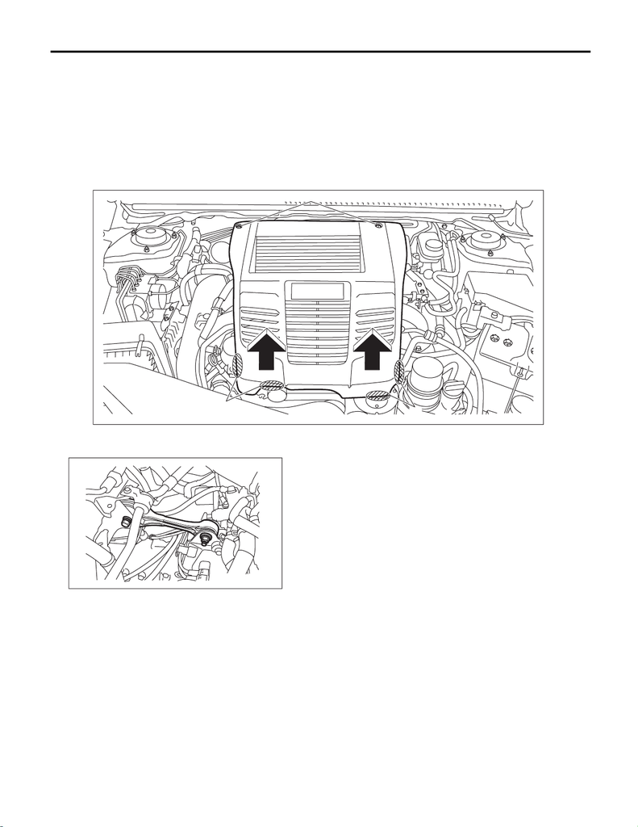

6MT(TY75)-36

Transmission Mounting System

MANUAL TRANSMISSION AND DIFFERENTIAL

4. Transmission Mounting System

A: REMOVAL

1. PITCHING STOPPER

1) Disconnect the ground cable from battery. <Ref. to NT-5, BATTERY, NOTE, Note.>

2) Remove the collector cover.

(1) Remove the clips (A).

(2) Hold the shaded area (B) by hand and carefully pull the RH side (C) upward.

(3) Hold the shaded area (D) by hand and carefully pull the LH side (E) upward.

3) Remove the intercooler. <Ref. to IN(w/o STI)-38, REMOVAL, Intercooler.>

4) Remove the pitching stopper.

EX-03204

(A)

(B)

(C)

(E)

(D)

MT-02689

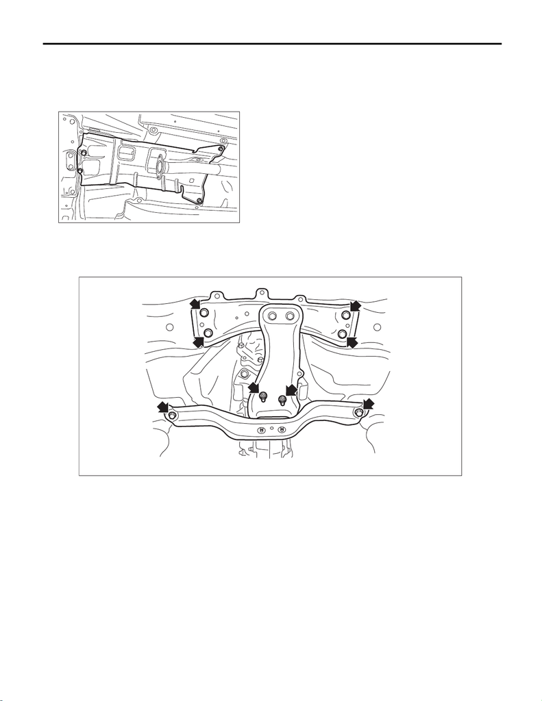

6MT(TY75)-37

Transmission Mounting System

MANUAL TRANSMISSION AND DIFFERENTIAL

2. CROSSMEMBER AND CUSHION RUBBER

1) Disconnect the ground cable from battery. <Ref. to NT-5, BATTERY, NOTE, Note.>

2) Lift up the vehicle.

3) Remove the center exhaust pipe (rear). <Ref. to EX(w/o STI)-35, REMOVAL, Center Exhaust Pipe.>

4) Remove the center exhaust cover.

5) Set the transmission jack under the transmission case.

CAUTION:

Always support the transmission case with a transmission jack.

6) Remove the front crossmember and the rear crossmember.

7) Remove the transmission cushion rubber.

MT-03072

MT-03184

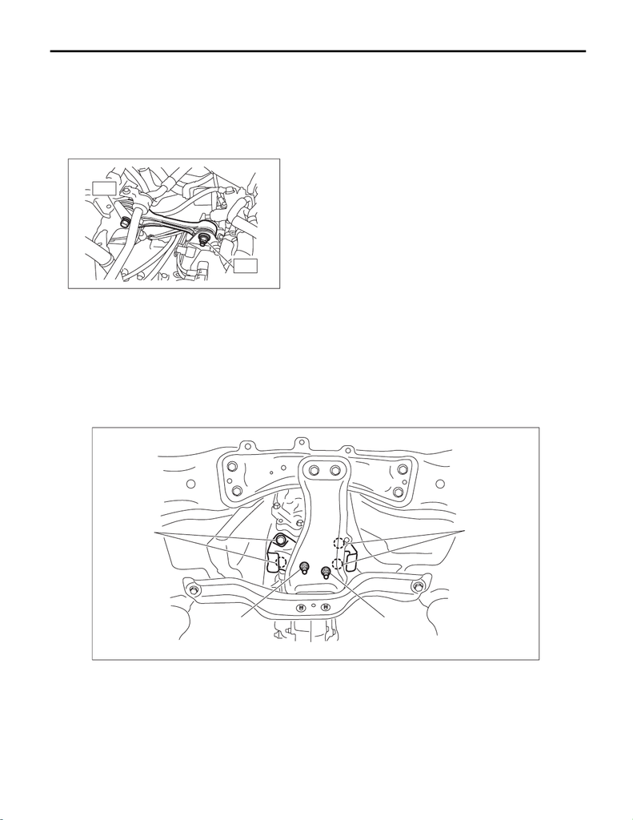

6MT(TY75)-38

Transmission Mounting System

MANUAL TRANSMISSION AND DIFFERENTIAL

B: INSTALLATION

1. PITCHING STOPPER

1) Install the pitching stopper.

Tightening torque:

T1: 50 N·m (5.1 kgf-m, 36.9 ft-lb)

T2: 58 N·m (5.9 kgf-m, 42.8 ft-lb)

2) Install the intercooler. <Ref. to IN(w/o STI)-41, INSTALLATION, Intercooler.>

3) Install the collector cover.

4) Connect the battery ground terminal. <Ref. to NT-5, BATTERY, NOTE, Note.>

2. CROSSMEMBER AND CUSHION RUBBER

1) Install the transmission cushion rubber to the transmission, and tighten the bolt (A).

2) Install the transmission cushion rubber to the center crossmember, and temporarily tighten the nut (B).

Tightening torque:

Bolt (A)

35 N·m (3.6 kgf-m, 25.8 ft-lb)

MT-02690

T1

T2

MT-03185

(A)(A)

(A)

(B)

(B)

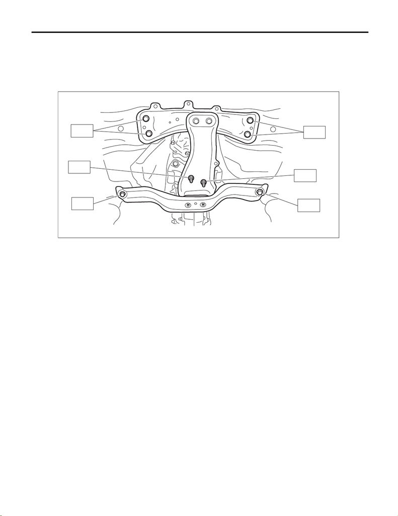

6MT(TY75)-39

Transmission Mounting System

MANUAL TRANSMISSION AND DIFFERENTIAL

3) Tighten the mounting bolts for front crossmember and rear crossmember.

4) Tighten the transmission cushion rubber mounting nut.

Tightening torque:

T1: 70 N·m (7.1 kgf-m, 51.6 ft-lb)

T2: 140 N·m (14.3 kgf-m, 103.3 ft-lb)

T3: 35 N·m (3.6 kgf-m, 25.8 ft-lb)

5) Remove the transmission jack.

6) Install the center exhaust cover.

Tightening torque:

18 N·m (1.8 kgf-m, 13.3 ft-lb)

7) Install the center exhaust pipe (rear). <Ref. to EX(w/o STI)-41, INSTALLATION, Center Exhaust Pipe.>

8) Lower the vehicle.

9) Connect the battery ground terminal. <Ref. to NT-5, BATTERY, NOTE, Note.>

C: INSPECTION

Check the following; repair or replace the faulty parts.

1. PITCHING STOPPER

aged.

2. CROSSMEMBER AND CUSHION RUBBER

wise damaged.

MT-03183

T1

T1

T3

T3

T2

T2